# Advanced joint modeling

Bayesian survival, longitudinal and joint models with INLA VIBASS 9, Valencia, Spain

Denis Rustand

July 8 and 9, 2026

We have a joint model that works for the trial. One marker, tumor size. One event, death.

Real studies are rarely that simple. Two questions push us further:

1. a patient has more than one marker.
2. a patient can have more than one event.

We answer both inside the same `joint()` call.

# Rebuilding the trial data

Run this block so the file stands on its own, it is the simulated cancer trial we have used all along, with correlated random effects.

```r
set.seed(1)
n = 500 # number of individuals
fw <- 5 # follow-up duration
b_0 = 1 # intercept
b_1 = -1 # slope
b_2 = 1 # trt
b_3 = 0.5 # trt x slope
b_e = 0.5 # residual error
mestime = seq(0, fw, 1) # measurement times
n_i <- length(mestime)
time = rep(mestime, n) # time column
id <- rep(1:n, each = n_i)
b1SD = 1 # random intercept standard deviation
b2SD = 0.7 # random slope standard deviation
cor_bintslo = 0.6 # correlation between the two random effects
cov_bintslo <- b1SD * b2SD * cor_bintslo
Sigma = matrix(c(b1SD^2, cov_bintslo,
                 cov_bintslo, b2SD^2), ncol = 2)
MVnorm <- rmvnorm(n, rep(0, 2), Sigma)
b1 <- rep(MVnorm[, 1], each = n_i) # random intercepts
b2 <- rep(MVnorm[, 2], each = n_i) # random slopes
trt <- rbinom(n, 1, 0.5)
trtY <- rep(trt, each = length(mestime))
linPred <- b_0 + b1 + (b_1 + b2) * time + b_2 * trtY + b_3 * trtY * time
Y <- rnorm(n_i * n, linPred, b_e)
datJM_Lt <- data.frame(id, time, Y, trt = trtY)
baseScale <- 0.1
s_1 <- 0.5 # random intercept effect on survival
s_2 <- 0.3 # random slope effect on survival
```

The same random effects feed a fine time grid for the permutation algorithm.

```r
gap2 <- 0.01 # fine grid for PermAlgo
mestime2 <- seq(0, fw, gap2) # measurement times
time2 <- rep(mestime2, n)
n_i2 <- length(mestime2)
trt2 <- rep(trt, each = n_i2)
b12 <- rep(MVnorm[, 1], each = n_i2)
b22 <- rep(MVnorm[, 2], each = n_i2)
```

# Two markers, one event

## The problem

Tumor size is not the only signal we collect.

- Say we also count new lesions at each visit.
- Tumor size is continuous. Lesion counts are counts.
- Different scales, different families.

We can fit two separate joint models, one per marker.

- That ignores the link between the two markers.
- A patient whose tumor grows fast may also gain lesions fast.
- Separate fits cannot see that shared patient-level signal.
- It also makes us pick which marker drives the risk, instead of letting both speak.

## The solution

One model. Two longitudinal submodels under one likelihood.

- `formLong` becomes a list of formulas.
- `family` becomes a vector, one entry per marker.
- `assoc` becomes a vector, one association per marker.
- An empty string means that marker has no direct link to the event.

The structure we are simulating from:

$$\begin{aligned}
\mathrm{E}[Y_{1i}(t)] &= \eta_{1i}(t) \quad \text{(continuous,
Gaussian)}\\
\log \mathrm{E}[Y_{2i}(t)] &= \eta_{2i}(t) \quad \text{(counts,
Poisson)}\\
\lambda_i(t) &= \lambda_0(t)\exp\{\gamma_1\,\eta_{1i}(t) +
\gamma_2\,\eta_{2i}(t)\}
\end{aligned}$$

- Two current-value links, one per marker.
- Each gamma is its own hazard ratio, the risk carried by that marker once we hold the other one fixed.

## Simulate the two markers

```r
set.seed(3)
CV_i1 <- b_0 + b12 + b_1*time2 + b_2*trt2 + b_3*trt2*time2
CV_i1L <- b_0 + b1 + b_1*time + b_2*trtY + b_3*trtY*time
CV_i2 <- b_0 + b22 + b_1*time2 + b_2*trt2 + b_3*trt2*time2
CV_i2L <- b_0 + b2 + b_1*time + b_2*trtY + b_3*trtY*time
DatTmp <- permalgorithm(n, n_i2, Xmat=matrix(c(CV_i1, CV_i2), ncol=2),
                        betas=c(s_1, s_2)) # association
DatTmp2 <- DatTmp[which(!duplicated(DatTmp$Id, fromLast = T)),
                  c("Id","Event","Stop")]
datJM7_S <- data.frame(id = 1:n, eventTimes = mestime2[DatTmp2$Stop+1],
                       eventIndic = DatTmp2$Event, trt = trt)
datJM_Lt$Y1 <- rnorm(n_i*n, CV_i1L, b_e) # first outcome Gaussian
datJM_Lt$Y2 <- rpois(n_i*n, exp(CV_i2L)) # second outcome Poisson
datJM7_L <- datJM_Lt[-unlist(sapply(1:n, function(x)
  which(datJM_Lt$time>=datJM7_S$eventTimes[datJM7_S$id==x] &
        datJM_Lt$id==x))),]
```

What this block does:

- Two markers from correlated random intercepts.
- The first is Gaussian, the second is counts.
- Both affect the risk of death through their current value.

## Fit it

```r
M_jmCV2 <- joint(formSurv = inla.surv(eventTimes, eventIndic) ~ -1,
                 formLong = list(Y1 ~ time * trt + (1 | id),
                                 Y2 ~ time * trt + (1 | id)),
                 dataSurv = datJM7_S, dataLong = datJM7_L,
                 family = c("gaussian", "poisson"), id = "id",
                 timeVar = "time", assoc = c("CV", "CV"))
summary(M_jmCV2)
```

```
## Longitudinal outcome (L1, gaussian)
##                         mean     sd 0.025quant 0.5quant 0.975quant
## Intercept_L1          1.0171 0.0710     0.8778   1.0171     1.1564
## time_L1              -0.9906 0.0213    -1.0325  -0.9906    -0.9488
## trt_L1                0.9000 0.1029     0.6982   0.9000     1.1018
## time:trt_L1           0.5409 0.0393     0.4638   0.5409     0.6178
## Res. err. (variance)  0.2322 0.0135     0.2070   0.2318     0.2600
##
## Random effects variance-covariance (L1)
##                mean     sd 0.025quant 0.5quant 0.975quant
## Intercept_L1 1.1247 0.0796     0.9773   1.1217     1.2899
##
## Longitudinal outcome (L2, poisson)
##                 mean     sd 0.025quant 0.5quant 0.975quant
## Intercept_L2  1.0203 0.0581     0.9054   1.0207     1.1334
## time_L2      -0.9702 0.0517    -1.0718  -0.9701    -0.8692
## trt_L2        0.8909 0.0777     0.7388   0.8908     1.0438
## time:trt_L2   0.4615 0.0622     0.3398   0.4614     0.5839
##
## Random effects variance-covariance (L2)
##                mean     sd 0.025quant 0.5quant 0.975quant
## Intercept_L2 0.5241 0.0452     0.4413    0.522     0.6191
##
## Survival outcome
##                               mean     sd 0.025quant 0.5quant 0.975quant
## Baseline risk (variance)_S1 0.6341 0.2389     0.2916   0.5922     1.2219
##
## Association longitudinal - survival
##            mean     sd 0.025quant 0.5quant 0.975quant
## CV_L1_S1 0.4288 0.0778     0.2766   0.4285     0.5831
## CV_L2_S1 0.3495 0.1006     0.1505   0.3499     0.5466
##
## log marginal-likelihood (integration)    log marginal-likelihood (Gaussian)
##                             -25557.07                             -25553.03
##
## Deviance Information Criterion:  7883.291
## Widely applicable Bayesian information criterion:  7841.436
## Computation time: 10.79 seconds
```

Reading the summary, top to bottom:

- Marker one first, then marker two.
- Then the survival part.
- Then two association parameters, one per marker.
- Both sit near the values I simulated from, 0.5 and 0.3.

The two association posteriors, side by side:

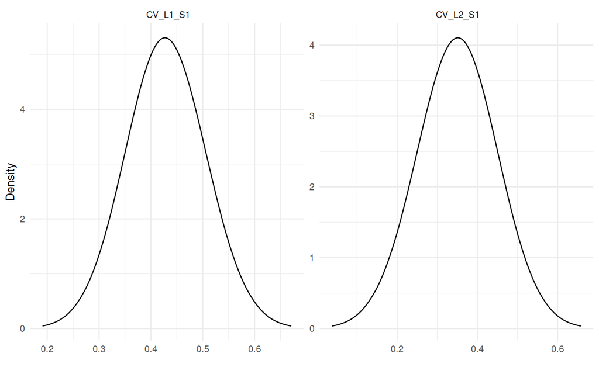

```r
jm_plots <- plot(M_jmCV2)
jm_plots$Associations
```

## Let the markers inform each other

We built the two markers from correlated random intercepts. The fit above kept them independent and ignored that link.

- One switch turns it on, `corLong = TRUE`.
- Now the random intercepts share a covariance.

```r
M_jmCV3 <- joint(formSurv = inla.surv(eventTimes, eventIndic) ~ -1,
                 formLong = list(Y1 ~ time * trt + (1 | id),
                                 Y2 ~ time * trt + (1 | id)),
                 dataSurv = datJM7_S, dataLong = datJM7_L, corLong = TRUE,
                 family = c("gaussian", "poisson"), id = "id",
                 timeVar = "time", assoc = c("CV", "CV"))
summary(M_jmCV3, sdcor = TRUE)
```

```
## Longitudinal outcome (L1, gaussian)
##                   mean     sd 0.025quant 0.5quant 0.975quant
## Intercept_L1    1.0177 0.0712     0.8781   1.0177     1.1573
## time_L1        -0.9868 0.0213    -1.0286  -0.9868    -0.9451
## trt_L1          0.8999 0.1031     0.6976   0.8999     1.1021
## time:trt_L1     0.5499 0.0391     0.4732   0.5499     0.6265
## Res. err. (sd)  0.4821 0.0140     0.4551   0.4819     0.5101
##
## Longitudinal outcome (L2, poisson)
##                 mean     sd 0.025quant 0.5quant 0.975quant
## Intercept_L2  1.0233 0.0581     0.9085   1.0236     1.1364
## time_L2      -0.9541 0.0515    -1.0555  -0.9540    -0.8536
## trt_L2        0.8863 0.0777     0.7342   0.8862     1.0391
## time:trt_L2   0.4606 0.0618     0.3398   0.4604     0.5822
##
## Random effects standard deviation / correlation
##                             mean     sd 0.025quant 0.5quant 0.975quant
## Intercept_L1              1.0637 0.0377     0.9916   1.0619     1.1394
## Intercept_L2              0.7261 0.0306     0.6687   0.7252     0.7876
## Intercept_L1:Intercept_L2 0.5967 0.0395     0.5150   0.5980     0.6683
##
## Survival outcome
##                               mean     sd 0.025quant 0.5quant 0.975quant
## Baseline risk (variance)_S1 0.7834 0.1456     0.5379   0.7697     1.1089
##
## Association longitudinal - survival
##            mean     sd 0.025quant 0.5quant 0.975quant
## CV_L1_S1 0.4021 0.0906     0.2248   0.4017     0.5817
## CV_L2_S1 0.3802 0.1180     0.1465   0.3807     0.6111
##
## log marginal-likelihood (integration)    log marginal-likelihood (Gaussian)
##                             -25476.25                             -25471.29
##
## Deviance Information Criterion:  7823.374
## Widely applicable Bayesian information criterion:  7795.103
## Computation time: 13.94 seconds
```

The takeaway:

- The estimated correlation recovers the true 0.6.
- A patient high on one marker tends to be high on the other.

# Two markers, two events

## The problem

Death is not the only thing that can happen.

- A patient can be hospitalized.
- Disease can recur.
- Different events may be informed by different markers.

Example:

- Maybe the current tumor level drives death.
- Maybe a patient’s baseline frailty, the random intercept, drives the second event.

Separate survival models per event cannot share the patient-level signal across events. The random effects are what carry a patient’s frailty from one event into the other.

## The solution

- `formSurv` becomes a list, one formula per event.
- `assoc` becomes a list, one element per marker.
- Inside each element, a vector with one entry per event.

The structure we are simulating from:

$$\begin{aligned}
\lambda_{1i}(t) &= \lambda_{10}(t)\exp\{\gamma_{11}\,\eta_{1i}(t) +
\gamma_{12}\,\eta_{2i}(t)\}\\
\lambda_{2i}(t) &= \lambda_{20}(t)\exp\{\gamma_{21}\,b_{1i0}\}
\end{aligned}$$

- Event one depends on both markers at their current value.
- Event two depends on only the baseline level of marker one, its random intercept.
- “CV” for the current-value link, “SRE_ind” for sharing a single random effect.

(here we assume no competing risk and no multi-state for simplicity).

## Simulate the second event

This block builds on the previous simulation. It keeps the event-one times and adds a second event driven by the random intercept of marker one.

```r
set.seed(3)
DatTmp <- permalgorithm(n, n_i2, Xmat=matrix(b12, ncol=1), betas=0.2)
DatTmp2$Event2 <- DatTmp[which(!duplicated(DatTmp$Id, fromLast = T)),
                         "Event"]
DatTmp2$Stop2 <- DatTmp[which(!duplicated(DatTmp$Id, fromLast = T)),
                         "Stop"]
datJM8_S <- data.frame(id = 1:n, eventTimes = mestime2[DatTmp2$Stop+1],
                       eventTimes2 = mestime2[DatTmp2$Stop2+1],
                       eventIndic = DatTmp2$Event,
                       eventIndic2 = DatTmp2$Event2, trt = trt)
datJM8_L <- datJM_Lt[-unlist(sapply(1:n, function(x)
  which((datJM_Lt$time>=datJM8_S$eventTimes[datJM8_S$id==x] |
         datJM_Lt$time>=datJM8_S$eventTimes2[datJM8_S$id==x]) &
        datJM_Lt$id==x))),]
```

## Fit it

```r
M_jmCV4 <- joint(formSurv = list(inla.surv(eventTimes, eventIndic) ~ -1,
                                inla.surv(eventTimes2, eventIndic2) ~ -1),
                 formLong = list(Y1 ~ time * trt + (1 | id),
                                 Y2 ~ time * trt + (1 | id)),
                 dataSurv = datJM8_S, dataLong = datJM8_L, corLong = TRUE,
                 family = c("gaussian", "poisson"), id = "id",
                 timeVar = "time", assoc = list(c("CV", "SRE_ind"),
                                                c("CV", "")))
summary(M_jmCV4, sdcor = TRUE)
```

```
## Longitudinal outcome (L1, gaussian)
##                   mean     sd 0.025quant 0.5quant 0.975quant
## Intercept_L1    1.0289 0.0707     0.8903   1.0289     1.1676
## time_L1        -0.9996 0.0344    -1.0669  -0.9996    -0.9321
## trt_L1          0.8840 0.1016     0.6847   0.8840     1.0833
## time:trt_L1     0.5764 0.0616     0.4555   0.5765     0.6973
## Res. err. (sd)  0.4876 0.0194     0.4512   0.4870     0.5273
##
## Longitudinal outcome (L2, poisson)
##                 mean     sd 0.025quant 0.5quant 0.975quant
## Intercept_L2  1.0377 0.0580     0.9230   1.0380     1.1504
## time_L2      -0.9645 0.0691    -1.1011  -0.9642    -0.8300
## trt_L2        0.8730 0.0772     0.7219   0.8729     1.0248
## time:trt_L2   0.4401 0.0836     0.2775   0.4396     0.6054
##
## Random effects standard deviation / correlation
##                             mean     sd 0.025quant 0.5quant 0.975quant
## Intercept_L1              1.0474 0.0391     0.9760   1.0458     1.1293
## Intercept_L2              0.7195 0.0322     0.6585   0.7184     0.7848
## Intercept_L1:Intercept_L2 0.5842 0.0412     0.4991   0.5860     0.6582
##
## Survival outcome (S1)
##                               mean     sd 0.025quant 0.5quant 0.975quant
## Baseline risk (variance)_S1 0.7906 0.1468     0.5402   0.7779      1.116
##
## Survival outcome (S2)
##                               mean     sd 0.025quant 0.5quant 0.975quant
## Baseline risk (variance)_S2 0.3721 0.1123     0.1974   0.3569     0.6363
##
## Association longitudinal - survival
##                       mean     sd 0.025quant 0.5quant 0.975quant
## CV_L1_S1            0.4341 0.0937     0.2493   0.4342     0.6182
## SRE_Intercept_L1_S2 0.2185 0.0635     0.0941   0.2183     0.3441
## CV_L2_S1            0.3540 0.1245     0.1097   0.3537     0.5998
##
## log marginal-likelihood (integration)    log marginal-likelihood (Gaussian)
##                             -25976.70                             -25969.92
##
## Deviance Information Criterion:  8940.559
## Widely applicable Bayesian information criterion:  8889.205
## Computation time: 21.07 seconds
```

- Marker one: CV with event one, SRE_ind with event two.
- Marker two: CV with event one, nothing with event two.
- Empty string = no link.

The three association posteriors:

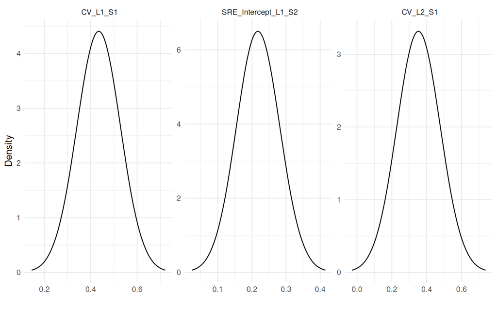

```r
jm_plots2 <- plot(M_jmCV4)
jm_plots2$Associations
```

- Two for event one, the current values of both markers.
- One for event two, the shared random intercept.

# Two more association structures

The main session covered SRE_ind, SRE, CV and CS. Each scales a shared component by a constant.

Think about these situations:

- Relationship between number of cigarettes smoked and the risk of lung cancer
- Relationship between BMI and all cause mortality

Two new association structures can deal with these tasks:

- Cumulative value. The whole (or part of) history of the marker, not just today.
- Non-linear. The effect of the marker can bend, not just scale.

Consider the current value of a single marker (evaluated at a fine grid):

```r
CV_i <- b_0 + b12 + (b_1 + b22) * time2 + b_2 * trt2 + b_3 * trt2 * time2
```

## Non-linear association

### The problem

Every structure so far scales a shared component by one constant.

$$\log HR = \gamma \cdot
h(\eta_i(t))$$

- Move the marker up by one unit, the log-risk shifts by the same $\gamma$ everywhere on the range.
- Interpretable, and often enough.
- Tumor size rising is bad, and more is worse. Monotone, so a flat scaling fits.

Real effects can bend in two ways.

- Non-monotone. Body mass index and mortality trace a U. Both ends raise risk. A flat scaling averages them into no association.
- Curved monotone. A marker can protect when low and harm when high, with the change per unit growing as the level moves out. A straight line on the log scale might lack flexibility.

### The solution

Replace the constant $\gamma$ with a function $f$ that depends on the shared component itself.

$$\lambda_i(t) =
\lambda_0(t)\exp\{f(h)\cdot h\},\qquad h = h(\eta_i(t))$$

- $f$ is now a value-dependent scaling.
- When $f$ is flat, we are back to the constant case.

Three nested levels, each one more flexible than the last.

| Level | `assoc` | Scaling $f(x)$ |
| --- | --- | --- |
| Linear | `"CV"` | $\gamma$ |
| Quadratic | `"L_CV"` | $\gamma_1+\gamma_2 x$ |
| Spline | `"NL_CV"` | $\gamma_1+\gamma_2 x+\mathrm{RW2}(x)$ |

- Linear. One hazard ratio for the whole range.
- Quadratic. The scaling gains a slope, so the log hazard ratio becomes a parabola. This alone captures a U or an inverted U.
- Spline. A second-order random walk adds a smooth deviation on top of the line. This reaches shapes a parabola cannot.

The prefix identifies the structure:

- Add `L_` for the linear scaling, so `"CV"` becomes `"L_CV"`.
- Add `NL_` for the spline, so `"CV"` becomes `"NL_CV"`.
- The same prefixes apply to the other structures, `"L_SRE"`, `"NL_SRE"`, `"L_CS"` and so on.

**A built-in safety net.** Each level collapses to the simpler one when the data give no evidence for non-linearity.

- Quadratic collapses to linear when the posterior for $\gamma_2$ sits near zero.
- Spline collapses to quadratic when the RW2 variance sits near zero.
- A penalized complexity prior on the RW2 precision pulls it toward zero unless the data push back.

Starting flexible costs nothing when the truth is simple. When the truth does suggest non-linearity, the extra terms stay in, and we can compare the models with standard criterion (WAIC, DIC).

**Knots.** The spline is defined over knots spread across the observed range of the shared component.

- `n_NL` sets the number of knots. Default 3.
- Three to five covers most real data. More only chases shapes that rarely appear.

> **Question.** For each scaling in the table, what shapes can the hazard ratio take across the range of the marker?

### Example

One marker. Its current value drives the risk through a curved effect, protective when low and harmful when high, with the per-unit effect growing as the value moves out from the center.

We simulate from that truth, fit the three levels, then let a formal comparison pick the winner. The block below stands on its own.

```r
set.seed(1)

# Config
n <- 500
beta <- c(-1.5, 0.3, 0.5, 0.2)
Sigma <- matrix(c(0.64, 0.072, 0.072, 0.09), 2, 2)
sigma_e <- 0.3
F_assoc <- function(x) x * log(x^2 + 1)^1.5 / 8 # curved effect on the log hazard

# Data generation
time_fine <- seq(0, 10, 0.001)
time_long <- seq(0, 10, 0.2)
trt <- rbinom(n, 1, 0.5)
re <- rmvnorm(n, sigma = Sigma)

# Survival
id_fine <- rep(1:n, each = length(time_fine))
time_fine_rep <- rep(time_fine, n)
trt_fine <- rep(trt, each = length(time_fine))
eta_fine <- beta[1] + re[id_fine, 1] +
  (beta[2] + re[id_fine, 2]) * time_fine_rep +
  beta[3] * trt_fine + beta[4] * time_fine_rep * trt_fine

surv <- permalgorithm(n, length(time_fine),
                      Xmat = as.matrix(F_assoc(eta_fine)),
                      eventRandom = round(rexp(n, 0.0001) + 1),
                      XmatNames = "assoc", betas = 1)
d_surv <- surv[c(which(diff(surv$Id) == 1), nrow(surv)),
               c("Id", "Event", "Stop")]
d_surv$Stop <- pmin(d_surv$Stop, length(time_fine) - 1)
d_surv$time <- time_fine[d_surv$Stop + 1]
d_surv$time[is.na(d_surv$time)] <- 10
d_surv <- data.frame(id = d_surv$Id, time = d_surv$time, event = d_surv$Event)

# Longitudinal
id_long <- rep(1:n, each = length(time_long))
time_long_rep <- rep(time_long, n)
trt_long <- rep(trt, each = length(time_long))
eta_long <- beta[1] + re[id_long, 1] +
  (beta[2] + re[id_long, 2]) * time_long_rep +
  beta[3] * trt_long + beta[4] * time_long_rep * trt_long
y <- rnorm(length(eta_long), eta_long, sigma_e)
d_long <- data.frame(id = id_long, time = time_long_rep, y = y, trt = trt_long)
d_long <- d_long[d_long$time <= d_surv$time[match(d_long$id, d_surv$id)], ]
```

What the block builds:

- A single Gaussian marker measured over time.
- A survival outcome whose log-risk follows `F_assoc` of the current value.
- The marker history cut at each patient’s event time.

Fit the three levels on the same data.

```r
formLong <- list(y ~ time * trt + (1 + time | id))
formSurv <- inla.surv(time, event) ~ -1

# Level 1 - linear
M1 <- joint(formLong = formLong, formSurv = formSurv,
            dataLong = d_long, dataSurv = d_surv,
            id = "id", timeVar = "time",
            assoc = "CV", basRisk = "rw2",
            control = list(int.strategy = "eb"))

# Level 2 - quadratic
M2 <- joint(formLong = formLong, formSurv = formSurv,
            dataLong = d_long, dataSurv = d_surv,
            id = "id", timeVar = "time",
            assoc = "L_CV", basRisk = "rw2",
            control = list(int.strategy = "eb"))

# Level 3 - spline
M3 <- joint(formLong = formLong, formSurv = formSurv,
            dataLong = d_long, dataSurv = d_surv,
            id = "id", timeVar = "time",
            assoc = "NL_CV", basRisk = "rw2",
            control = list(int.strategy = "eb"))
```

- `basRisk = "rw2"` gives the baseline hazard its own flexible shape, so the association is not left to absorb baseline structure.
- The empirical Bayes integration keeps the three fits fast and stable.

### Which level do the data support?

`joint.compare` puts the three side by side on WAIC, with a standard error and a test on each difference.

```r
joint.compare(M1, M2, M3)
```

```
##   model1 model2 dWAIC  se    z     p better sig
## 1     M1     M2  16.2 6.9 2.33 0.020     M2   *
## 2     M1     M3  31.6 9.5 3.32 0.001     M3  **
## 3     M2     M3  15.5 5.6 2.74 0.006     M3  **
```

Reading the table:

- Linear to quadratic is favored. The effect is not flat.
- Quadratic to spline is favored again. A parabola is not enough, the shape needs the random walk.
- The spline wins. Here the flexibility earns its keep.

The fitted spline association:

```r
summary(M3, sdcor = TRUE)
```

```
## Longitudinal outcome (gaussian)
##                   mean     sd 0.025quant 0.5quant 0.975quant
## Intercept_L1   -1.5156 0.0532    -1.6198  -1.5156    -1.4113
## time_L1         0.2903 0.0208     0.2496   0.2903     0.3311
## trt_L1          0.4735 0.0784     0.3197   0.4735     0.6272
## time:trt_L1     0.1843 0.0310     0.1236   0.1843     0.2450
## Res. err. (sd)  0.2999 0.0023     0.2955   0.2999     0.3046
##
## Random effects standard deviation / correlation (L1)
##                        mean     sd 0.025quant 0.5quant 0.975quant
## Intercept_L1         0.8601 0.0282     0.8056   0.8600     0.9152
## time_L1              0.2966 0.0116     0.2753   0.2960     0.3192
## Intercept_L1:time_L1 0.2834 0.0343     0.2134   0.2839     0.3502
##
## Survival outcome
##                               mean     sd 0.025quant 0.5quant 0.975quant
## Baseline risk (variance)_S1 0.1798 0.0284     0.1323   0.1768     0.2439
##
## Association longitudinal - survival
##                         mean     sd 0.025quant 0.5quant 0.975quant
## Beta0 for NL_CV_L1_S1 0.4324 0.0614     0.3137   0.4317     0.5555
## Beta1 for NL_CV_L1_S1 0.0138 0.2099    -0.4212   0.0212     0.4037
## Beta2 for NL_CV_L1_S1 0.3252 0.0799     0.1726   0.3237     0.4871
## Beta3 for NL_CV_L1_S1 0.0131 0.0600    -0.0999   0.0114     0.1362
## Beta4 for NL_CV_L1_S1 0.0975 0.0863    -0.0398   0.0883     0.2926
##
## log marginal-likelihood (integration)    log marginal-likelihood (Gaussian)
##                             -40293.20                             -40283.72
##
## Deviance Information Criterion:  6331.664
## Widely applicable Bayesian information criterion:  6346.682
## Computation time: 14.14 seconds
```

- Five association parameters. An intercept, a slope, then three for the random walk.
- Some sit near zero, others clearly away from it.

> **Question.** The linear model reports a single hazard ratio. Why can one number mislead for this marker?

> **Answer.** The effect changes sign and steepness across the range. A single value reports an average that fits neither the low end nor the high end.

### Recovered effect

With linear:

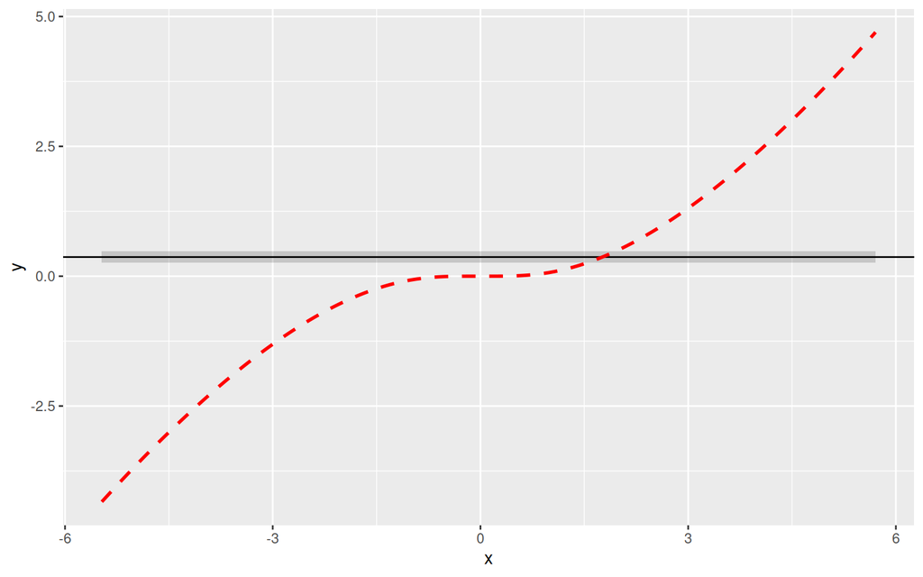

```r
q <- as.numeric(M1$summary.hyperpar["Beta for CV_L1_S1", 3:5])
grid <- plot(M2)$NL$data$x
p_lhr <- ggplot(data.frame(x = grid), aes(x)) + geom_ribbon(aes(ymin = q[1], ymax = q[3]), alpha = 0.2) + geom_hline(yintercept = q[2])
p_lhr +
  geom_line(data = data.frame(x = grid, y = F_assoc(grid)),
            aes(x = x, y = y),
            colour = "red", linetype = "dashed", linewidth = 1)
```

With quadratic:

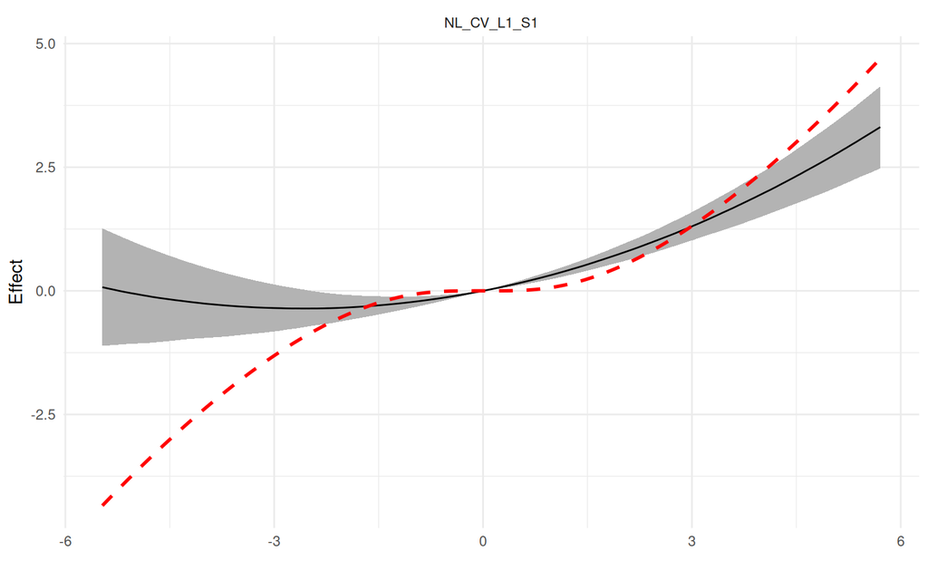

```r
p_lhr <- plot(M2)$NL
grid <- p_lhr$data$x
p_lhr +
  geom_line(data = data.frame(x = grid, y = F_assoc(grid)),
            aes(x = x, y = y),
            colour = "red", linetype = "dashed", linewidth = 1)
```

Now the spline:

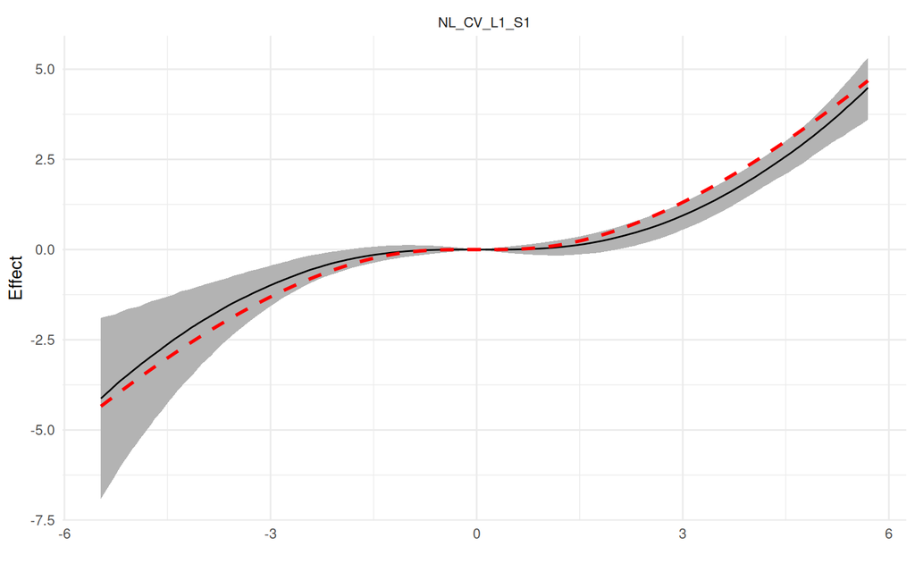

```r
p_lhr <- plot(M3)$NL
grid <- p_lhr$data$x
p_lhr +
  geom_line(data = data.frame(x = grid, y = F_assoc(grid)),
            aes(x = x, y = y),
            colour = "red", linetype = "dashed", linewidth = 1)
```

- The band is the spline estimate.
- The red dashed line is the truth.

### Reading the curve

- The log hazard ratio crosses zero Below the center the marker protects, above it the marker harms.
- The per-unit effect is not constant. It grows as the patient moves toward the edges.
- The curve is drawn where the model has fitted values. The tails carry little information, so read them with care.

### Before you use these

- These structures are validated by simulation.
- Flexibility needs data.
- The same idea opens a door to time-dependent effects $\gamma(t)$, not yet built.

## Cumulative value, the area under the curve

So far the risk at time $t$ reads the marker at time $t$.

Sometimes that is the wrong clock.

- Maybe it is not today’s tumor size that matters.
- Maybe it is the total burden a patient has carried.
- The area under the marker curve up to $t$.

Cumulative exposure. A patient who sat at a high tumor size for a year has a different risk profile compared to one who spiked only yesterday.

The structure:

$$\lambda_i(t) =
\lambda_0(t)\exp\left(\gamma \cdot
\int_{0}^{t}\eta_i(s)\,ds\right)$$

- The hazard scales the integral of the marker, not its current level.
- One parameter, gamma, the cumulative exposure effect.

This one has no keyword. We build it on top of a current-value model with a weight matrix.

First the cumulative values and the event times that depend on them.

```r
set.seed(4)
CUM_CV_i <- rep(NA, length(CV_i))
for (i in 1:n) {
  CUM_CV_i[(n_i2*(i-1)+1):((n_i2*i))] <- cumsum(
    c(0, CV_i[(n_i2*(i-1)+1):((n_i2*i)-1)]) * gap2)
}
DatTmp <- permalgorithm(n, n_i2, Xmat = matrix(CUM_CV_i, ncol = 1), betas = 0.1)
DatTmp2 <- DatTmp[which(!duplicated(DatTmp$Id, fromLast = T)),
                  c("Id","Event","Stop")]
datAUC_S <- data.frame(id = 1:n, eventTimes = mestime2[DatTmp2$Stop+1],
                       eventIndic = DatTmp2$Event, trt = trt)
datAUC_L <- datJM_Lt[-unlist(sapply(1:n, function(x)
  which(datJM_Lt$time>=datAUC_S$eventTimes[datAUC_S$id==x] &
          datJM_Lt$id==x))),]
```

Set up a current-value model but hold the fit with `run = FALSE`.

```r
M_auc0 <- joint(formSurv = inla.surv(eventTimes, eventIndic) ~ -1,
                formLong = Y ~ time * trt + (1 + time | id),
                dataSurv = datAUC_S, dataLong = datAUC_L,
                id = "id", timeVar = "time", assoc = "CV",
                run = FALSE)
```

The weights block turns each interval’s value into a running integral, scaled by the length of every interval up to $t$.

```r
w <- na.omit(M_auc0$.args$data$E..coxph)
w.idx <- na.omit(M_auc0$.args$data$baseline1.hazard.idx)
w.size <- length(M_auc0$.args$data$baseline1.hazard.values)
maxSize <- w.size == length(M_auc0$.args$data$baseline1.hazard.values)
nA <- length(w)
nT <- length(M_auc0$.args$data$Intercept_L1)
j.acc <- 0
ijx <- list(i = rep(0L, w.size * nA),
            j = rep(0L, w.size * nA),
            x = rep(0.0, w.size * nA))
nacc <- 0
for (i in 1:nA) {
  iw <- tail(1:w.idx[i], w.size)
  ni <- length(iw)
  if ((i > 1) & (w.idx[i] == 1)) j.acc <- j.acc + w.idx[i-1]
  jj <- j.acc + iw
  w0 <- w[jj]
  fixw <- (!maxSize & tail(w0, 1) < (0.99 * w0[1]))
  if ((length(jj) > 1) && fixw) {
    iw <- tail(1:w.idx[i], w.size + 1)
    ni <- length(iw)
    jj <- j.acc + iw
    w0 <- w[jj]
    w0[1] <- w0[1] - tail(w0, 1)
  }
  ijx$i[nacc + 1:ni] <- i
  ijx$j[nacc + 1:ni] <- jj
  ijx$x[nacc + 1:ni] <- w0
  nacc <- nacc + ni
}
A0 <- sparseMatrix(i = ijx$i[1:nacc], j = ijx$j[1:nacc], x = ijx$x[1:nacc])
Adata <- rbind(sparseMatrix(i = 1, j = 1, x = 0, dims = c((nT - nA), nA)), A0)
inla.as.sparse(A0[1:10, 1:10])
```

```
## 10 x 10 sparse Matrix of class "dgTMatrix"
##
##  [1,] 0.3113333 .         .         .         .         .         .
##  [2,] 0.3113333 0.3113333 .         .         .         .         .
##  [3,] 0.3113333 0.3113333 0.3113333 .         .         .         .
##  [4,] 0.3113333 0.3113333 0.3113333 0.3113333 .         .         .
##  [5,] 0.3113333 0.3113333 0.3113333 0.3113333 0.3113333 .         .
##  [6,] 0.3113333 0.3113333 0.3113333 0.3113333 0.3113333 0.3113333 .
##  [7,] 0.3113333 0.3113333 0.3113333 0.3113333 0.3113333 0.3113333 0.3113333
##  [8,] 0.3113333 0.3113333 0.3113333 0.3113333 0.3113333 0.3113333 0.3113333
##  [9,] 0.3113333 0.3113333 0.3113333 0.3113333 0.3113333 0.3113333 0.3113333
## [10,] 0.3113333 0.3113333 0.3113333 0.3113333 0.3113333 0.3113333 0.3113333
##
##  [1,] .         .         .
##  [2,] .         .         .
##  [3,] .         .         .
##  [4,] .         .         .
##  [5,] .         .         .
##  [6,] .         .         .
##  [7,] .         .         .
##  [8,] 0.3113333 .         .
##  [9,] 0.3113333 0.3113333 .
## [10,] 0.3113333 0.3113333 0.3113333
```

Each row is one follow-up interval. It carries the running sum of the marker over all earlier intervals, weighted by their length. We drop this matrix into the model through `A.local` and run.

```r
M_auc0$.args$data$WCUM <- rep(0, nT)
M_auc0$.args$formula <- as.formula(paste(c("Yjoint ~ -1 ",
   attr(terms(M_auc0$.args$formula), which = "term.labels")[1:9],
   "+ f(CV_L1_S1, WCUM, copy = 'uv1', hyper = list(beta = list(
   fixed = FALSE, param = c(0, 0.01), initial = 0.1)),
   A.local = Adata)"), collapse = "+"))
M_auc <- joint.run(M_auc0)
summary(M_auc)
```

```
## Longitudinal outcome (gaussian)
##                         mean     sd 0.025quant 0.5quant 0.975quant
## Intercept_L1          1.0399 0.0694     0.9037   1.0399     1.1760
## time_L1              -0.9185 0.0663    -1.0484  -0.9185    -0.7883
## trt_L1                0.8798 0.1002     0.6832   0.8798     1.0763
## time:trt_L1           0.3602 0.0960     0.1719   0.3601     0.5485
## Res. err. (variance)  0.2517 0.0204     0.2149   0.2505     0.2951
##
## Random effects variance-covariance (L1)
##                        mean     sd 0.025quant 0.5quant 0.975quant
## Intercept_L1         1.0275 0.0826     0.8764   1.0264     1.2010
## time_L1              0.5441 0.0584     0.4373   0.5412     0.6682
## Intercept_L1:time_L1 0.4894 0.0593     0.3789   0.4866     0.6022
##
## Survival outcome
##                               mean    sd 0.025quant 0.5quant 0.975quant
## Baseline risk (variance)_S1 0.1727 0.096     0.0377   0.1568     0.4002
##
## Association longitudinal - survival
##            mean     sd 0.025quant 0.5quant 0.975quant
## CV_L1_S1 0.0678 0.0157     0.0368   0.0678     0.0988
##
## log marginal-likelihood (integration)    log marginal-likelihood (Gaussian)
##                             -13914.76                             -13910.74
##
## Deviance Information Criterion:  4337.265
## Widely applicable Bayesian information criterion:  4291.377
## Computation time: 10.99 seconds
```

- `CV_L1_S1` is now the cumulative exposure effect.
- A larger area under the tumor curve means a higher risk of death.

> **Question:** When would cumulative value beat current value for a marker in our trial?

> **Answer.** When risk builds from exposure over time, not from the level on any single day.

# Where this leaves us

Same engine, the whole way through.

- We never left `joint()`.
- Single formulas became lists. A single family became a vector. A single association became a vector, then a grid.
- Two new association structures.

The association you pick is usually a clinical choice, not a fit choice.

- Shared random effects. Individual deviation drives the risk.
- Current value. Today’s level drives risk.
- Current slope. The trend drives risk.
- Cumulative. The history / accumulated exposure drives risk.
- Non-linear. The effect changes with the level.

Other extensions follow similarly, such as lagged effects or specific windows of exposure.

> **Question:** We modeled two events as if a patient could have both. For death against progression in our trial, why might that assumption need a second look?

> **Answer.** Death stops everything, so the two events compete, i.e., competing risks.